# FederalGiving

Issy Belzil

2017-12-05

#### 2. Are there differences in donation patterns across the three types of classifications - Engineer/Math-Stat/Scientist - across different years for house, senate, and presidential elections, across different years.

```r
House = filter(science_federal_giving, cmte_tp == "H")
Senate = filter(science_federal_giving, cmte_tp == "S")
President = filter(President, cmte_tp == "P")

House = filter(House,state !="AP")
House = filter(House,state !="DC")
House = filter(House,state !="PR")
House = filter(House,state !="VI")
House = filter(House,state !="ZZ")
House = filter(House,state !="GU")

Senate = filter(Senate,state !="AP")
Senate = filter(Senate,state !="DC")
Senate = filter(Senate,state !="PR")
Senate = filter(Senate,state !="VI")
Senate = filter(Senate,state !="ZZ")
Senate = filter(Senate,state !="GU")

President = filter(President,state !="AP")
President = filter(President,state !="DC")
President = filter(President,state !="PR")
President = filter(President,state !="VI")
President = filter(President,state !="ZZ")
President = filter(President,state !="GU")
```

```r
Year2008 = filter(President, cycle == "2008", classification == "Math-Stat")
Year2008.1= filter(President, cycle == "2008")
Year2012 = filter(President, cycle == "2012")
Year2016 = filter(President, cycle == "2016")
```

Find average per state

```r
Av2008=Year2008%>%group_by(state)%>%summarize(mean =mean(`2016_dollars`))
Av2012=Year2012%>%group_by(state)%>%summarize(mean =mean(`2016_dollars`))
Av2016=Year2016%>%group_by(state)%>%summarize(mean =mean(`2016_dollars`))
```

```r
House.1=House%>%group_by(state, cycle)%>%summarize(mean =mean(`2016_dollars`))
House.1 <- na.omit(House.1)
```

### House of Representative Study

```r
House
```

```
## # A tibble: 56,896 x 13
##                                                       cmte_nm   cmte_id
##                                                         <chr>     <chr>
##  1                              A LOT OF PEOPLE FOR DAVE OBEY C00017830
##  2 A WHOLE LOT OF PEOPLE FOR GRIJALVA CONGRESSIONAL COMMITTEE C00374058
##  3 A WHOLE LOT OF PEOPLE FOR GRIJALVA CONGRESSIONAL COMMITTEE C00374058
##  4 A WHOLE LOT OF PEOPLE FOR GRIJALVA CONGRESSIONAL COMMITTEE C00374058
##  5 A WHOLE LOT OF PEOPLE FOR GRIJALVA CONGRESSIONAL COMMITTEE C00374058
##  6 A WHOLE LOT OF PEOPLE FOR GRIJALVA CONGRESSIONAL COMMITTEE C00374058
##  7                                ABEL MALDONADO FOR CONGRESS C00493379
##  8                                   ABERCROMBIE FOR CONGRESS C00247379
##  9                           ADAM CLAYTON POWELL FOR CONGRESS C00542761
## 10                                ABEL MALDONADO FOR CONGRESS C00493379
## # ... with 56,886 more rows, and 11 more variables: cmte_tp <chr>,
## #   cmte_pty <chr>, cand_name <chr>, cand_pty_affiliation <chr>,
## #   cleaned_name <chr>, city <chr>, state <chr>, zip_code <int>,
## #   classification <chr>, cycle <int>, `2016_dollars` <dbl>
```

```r
House.2=House%>%group_by(state, cycle, classification)%>%summarize(mean =mean(`2016_dollars`))
House.2 <- na.omit(House.2)
```

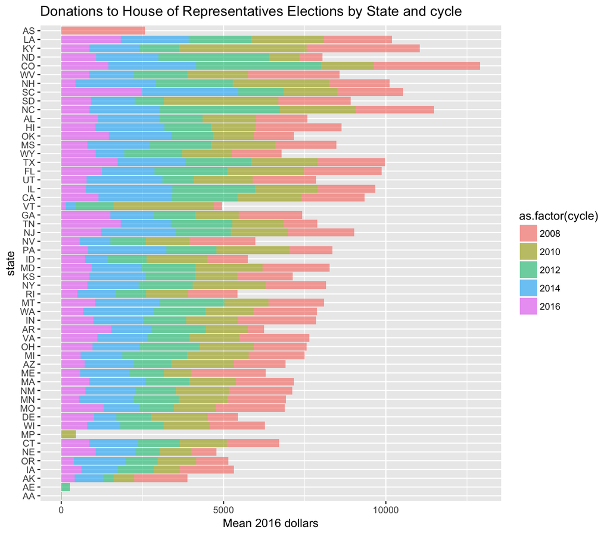

```r
housebig <- ggplot(data = House.2, aes(x=reorder(state, mean),  y=mean, fill=as.factor(cycle))) + geom_bar(stat="identity", alpha=.60) + coord_flip()+ labs(list(title = "Donations to House of Representatives Elections by State and cycle", x = "state", y = "Mean 2016 dollars"))

plot(housebig)
```

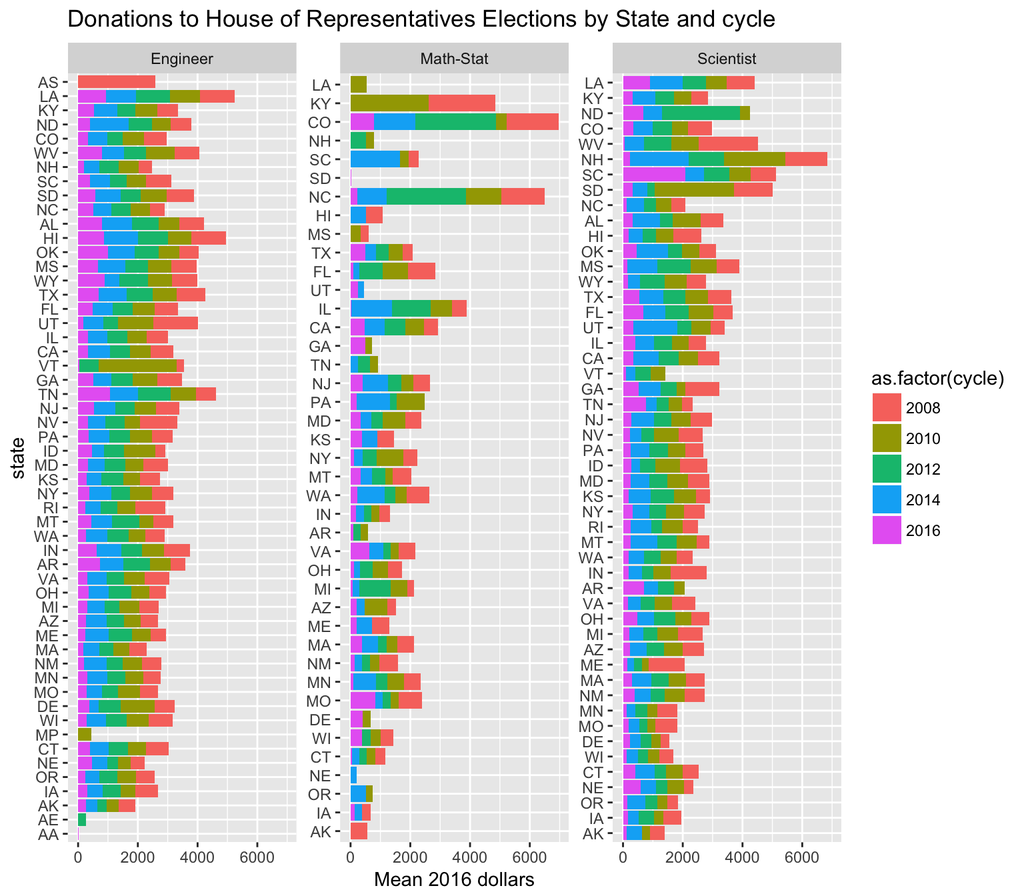

```r
housebig + geom_bar(stat="identity") + facet_wrap(~classification, scales="free_y")
```

The purpose of these graphs were to see how the three different classifications of scientist: Engineers, Math-Statistician, and Scientists differentiated their donation spending across different years and states to House of Representative campaigns. These dollar amounts have all been converted into 2016 USD dollar amounts.

Analysis:

Immediately, the Math-Statisticians stand out for donating the lowest amount of money in general, dramatically lower than the Engineers and Scientists. Although, Math-Statisticians from Kentucky and Colorado have given some of the highest amounts of money to House of Rep. campaigns in total from the years 2008 to 2016.

Overall, 2016 had the lowest amounts of donations to House of Rep. campaigns in total from all of the years studied across all the occupations.

### Senate Study

```r
Senate = filter(science_federal_giving, cmte_tp == "S")
Senate.1=Senate%>%group_by(state, cycle)%>%summarize(mean =mean(`2016_dollars`))
Senate.1 <- na.omit(Senate.1)
```

```r
Senate.2=Senate%>%group_by(state, cycle, classification)%>%summarize(mean =mean(`2016_dollars`))
Senate.2 <- na.omit(Senate.2)
```

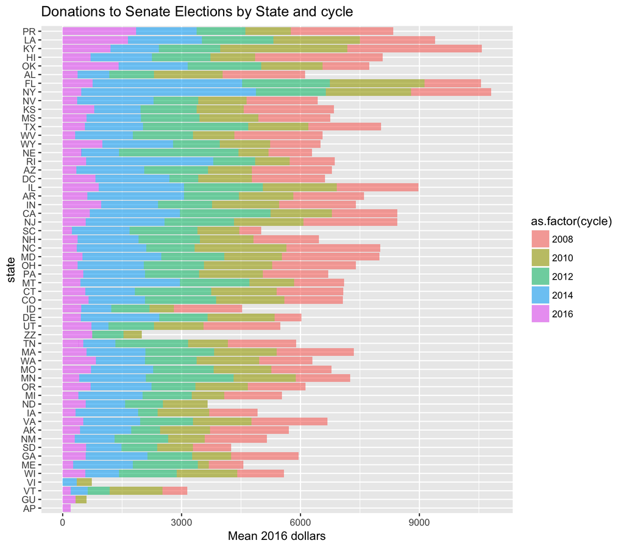

```r
senatebig <- ggplot(data = Senate.2, aes(x=reorder(state, mean),  y=mean, fill=as.factor(cycle))) + geom_bar(stat="identity", alpha=.60) + coord_flip()+ labs(list(title = "Donations to Senate Elections by State and cycle", x = "state", y = "Mean 2016 dollars"))

plot(senatebig)
```

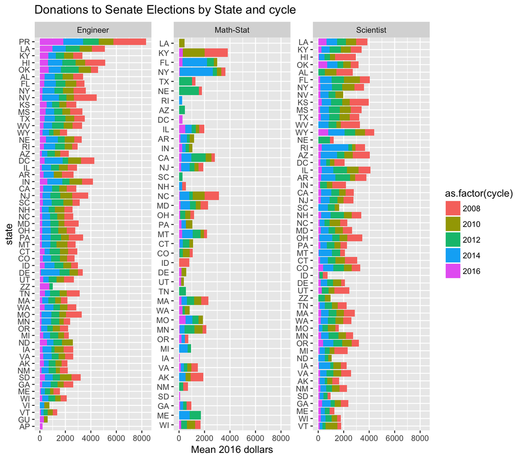

```r
senatebig + geom_bar(stat="identity") + facet_wrap(~classification, scales="free_y")
```

Analysis

Overall, Engineers are the most consistent donors across the states and across the years observed, with Math-Statisticians being the most volatile.

### Presidential Election and Campaign Study

```r
President = filter(President, cmte_tp == "P")
President.1=President%>%group_by(state, cycle)%>%summarize(mean =mean(`2016_dollars`))
President.1 <- na.omit(President.1)
```

```r
President.2=President%>%group_by(state, cycle, classification)%>%summarize(mean =mean(`2016_dollars`))
President.2 <- na.omit(President.2)
```

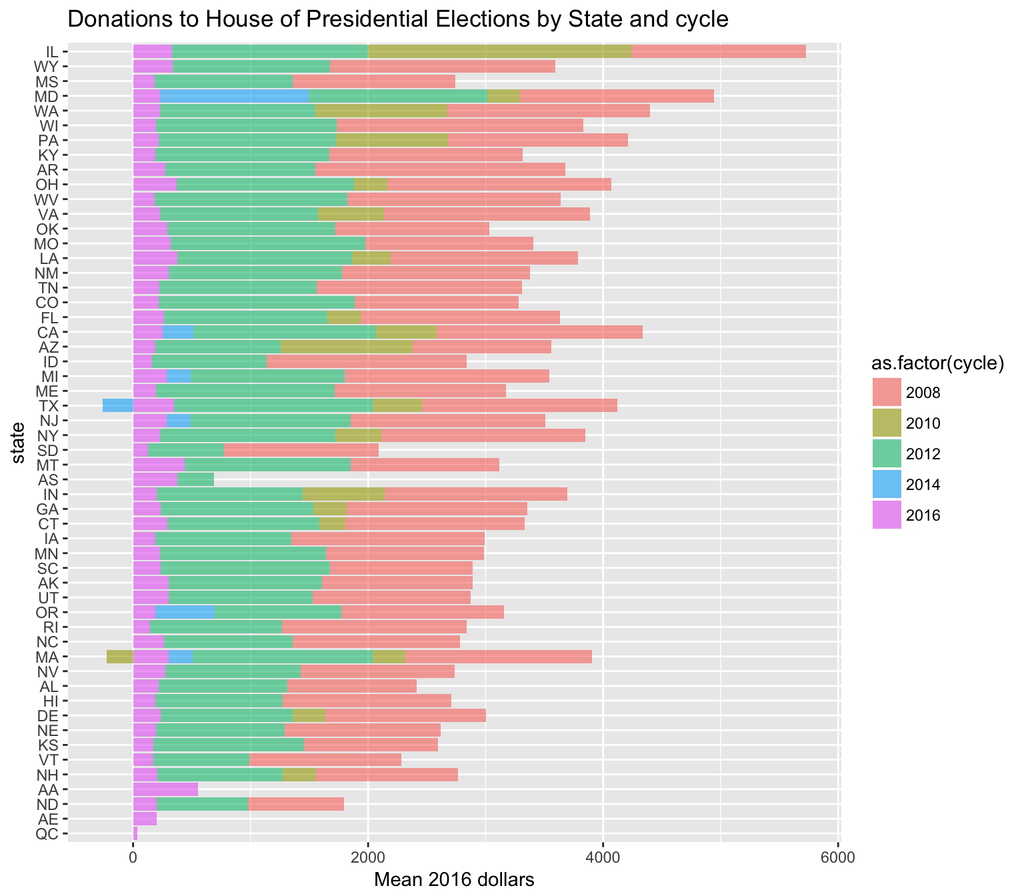

```r
Presidentbig <- ggplot(data = President.2, aes(x=reorder(state, mean),  y=mean, fill=as.factor(cycle))) + geom_bar(stat="identity", alpha=.60) + coord_flip()+ labs(list(title = "Donations to House of Presidential Elections by State and cycle", x = "state", y = "Mean 2016 dollars"))

plot(Presidentbig)
```

2016 was the lowest year for Presidential donations out of the years observed by a significant amount. The 2010 and 2014 years collected can assumed to be donations for midterms with many states not showing any donations during those years. The years 2008 and 2012 can be observed to have similar donation amounts, and thus the significant drop for the 2016 election is curious. 2016 was a tulmultuous election year with a lot of polarization of candidates, which may explain for the drop off.

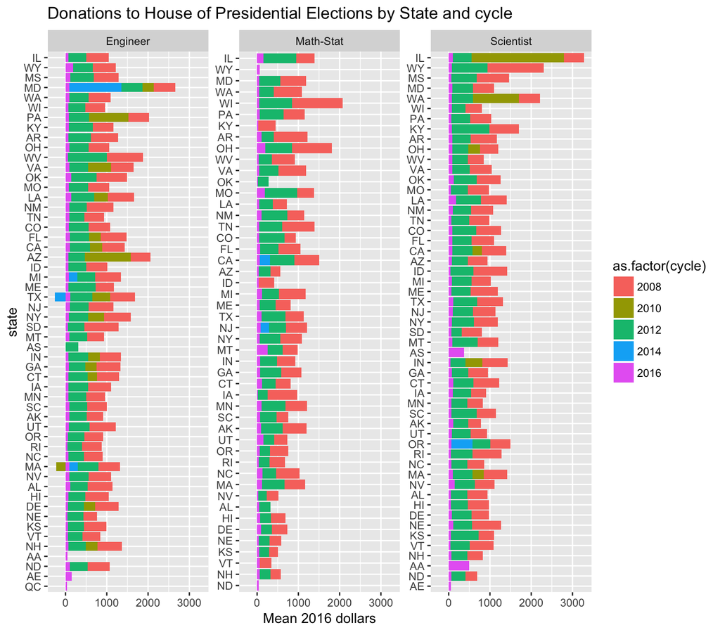

```r
Presidentbig + geom_bar(stat="identity") + facet_wrap(~classification, scales="free_y")
```

Analysis

To compare donations from Presidential campaigns to Senetorial and House of Rep. campaigns, the three types of scientists donate much more similarily for Presidential elections. Whereas when donating to Senate and House of Rep. Engineers were clearly the most giving, the champion classification for donating to Presidential races is a lot harder to tell.

Math-Statisticians across the 50 states are much more consistent with donating for Presidential elections than the other races. In Senate and House of Rep. races, you could infer, Math-Statisticians care less for politics overall because of the small donations. But in the Presidential campaigns, the occupation classification refutes the hypothesis, with donation amounts similar to the other two classifications.

#### THANKS FOR THE GREAT YEAR!!! R For Life!

## Mikaela & Issy

```r
President$classification=as.factor(President$classification)
President$cycle=as.factor(President$cycle)
President$`2016_dollars`=as.numeric(President$`2016_dollars`)
```

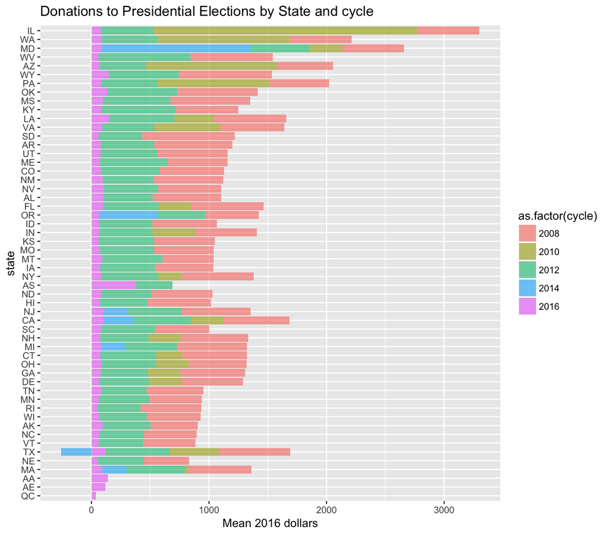

```r
ggplot(data = President.1, aes(x=reorder(state, mean),  y=mean, fill=as.factor(cycle))) + geom_bar(stat="identity", alpha=.60) + coord_flip()+ labs(list(title = "Donations to Presidential Elections by State and cycle", x = "state", y = "Mean 2016 dollars"))
```